# Reproducible Research: Peer Assessment 1

## Loading and preprocessing the data

### Import Data

```r
rawdata<-read.csv("activity/activity.csv")

#New data set with NA's removed
filterNA<-complete.cases(rawdata)
rawdataNoNA<-rawdata[filterNA,]
```

## What is mean total number of steps taken per day?

### Histogram of total number of steps taken each day (NA’s removed)

I use the **sqldf** package for aggregating data!

```r
library("sqldf")
aggdata<-sqldf("SELECT date, sum(steps) AS totalsteps
                FROM rawdataNoNA
                GROUP BY date
                ORDER BY date")
```

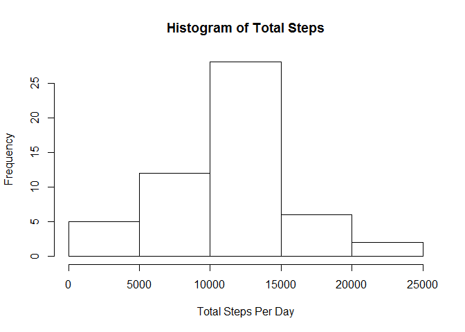

```r
hist(aggdata$totalsteps, main = "Histogram of Total Steps", xlab = "Total Steps Per Day")
```

### The mean and median of steps taken per day

```
## [1] "The mean is 10766.1886792453"
```

```
## [1] "The median is 10765"
```

## What is the average daily activity pattern?

### Time Series Plot of steps averaged across days

First I calcuated the averages, then made the graph below using ggplot2.

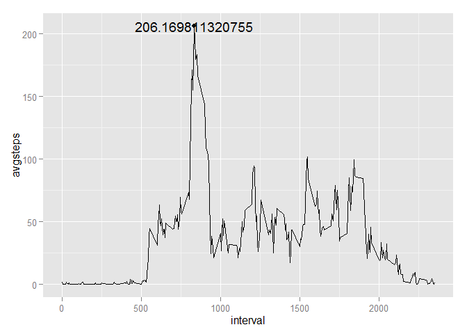

The interval that contains the max average steps is 835.

## Imputing missing values

The number of NA’s is

```
## [1] 2304
```

I will use the mean for the 5-minute intervals to replace the NA’s. Below is the code. The dataset cleanupNA will all the NA’s replaced with the mean value of the corresponding interval

```r
#Use Mean's to replace NA's
cleanupNA<-merge(rawdata,aggdata2, by="interval")

i<-1
loopend<-dim(cleanupNA)[1]

for (i in 1:loopend) {
    if (is.na(cleanupNA[i,2])==TRUE){
        cleanupNA[i,2]<-cleanupNA[i,4]
    }
}


cleanupNA<-sqldf("SELECT * FROM cleanupNA ORDER BY date, interval, steps")
```

Below is the new histogram

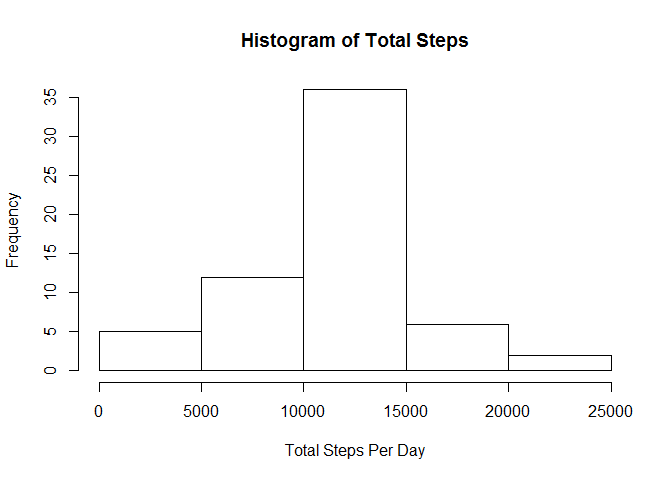

```
## [1] "The new mean is 10766.1886792453"
```

```
## [1] "The new median is 10766.1886792453"
```

After replacing the NA’s with the mean of their respective interval, we see the median and the mean are equivalent now.

## Are there differences in activity patterns between weekdays and weekends?

### Weekdays vs. Weekends patterns

```r
#add weekday factor
i <- 1
loopend<- dim(cleanupNA)[1]

#factor: 1 = weekend, 2 = weekday
for (i in 1:loopend){

    if (weekdays( as.Date(cleanupNA$date[i])) %in% c("Saturday","Sunday")){
        cleanupNA$factor[i] = "weekend"
    } else {
        cleanupNA$factor[i] = "weekday"
    }
}

cleanupNA$factor <- as.factor(cleanupNA$factor)
```

Below is the graph of the average steps factored across weekdays or weekends

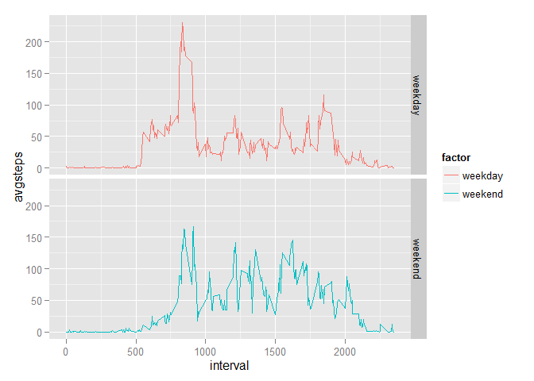

Based on the plots, it looks like the number of stephs in the earlier part of the day are much higher for weekdays and as they day progresses, they taper off. For weekends however, they number of steps are a bit lower initially, however they stay consistent throughout the majority of the day.